# STA380 Homework 1

Nick Scheifler

# Probability

## Problem A

Visitors to your website are asked to answer a single survey question before they get access to the content on the page. Among all of the users, there are two categories: Random Clicker (RC), and Truthful Clicker (TC). There are two possible answers to the survey: yes and no. Random clickers would click either one with equal probability. You are also giving the information that the expected fraction of random clickers is 0.3.

After a trial period, you get the following survey results: 65% said Yes and 35% said No.

What fraction of people who are truthful clickers answered yes?

### Given:

P(RC) = .3 P(TC) = .7

P(Y|RC) = .5 P(N|RC) = .5

P(Y) = .65 P(N) = .35

### Solve for P(Y|TC).

#### Using the rule of total probability:

P(Y) = P(Y,RC) + P(Y,TC) = P(Y|RC) x P(RC) + P(Y|TC) x P(TC) #### Insert known values .65 = .5 x .3 + P(Y|TC) x .7 #### Isolate P(Y|TC) algebraically and there you have it P(Y|TC) = 5/7

## Problem B

Imagine a medical test for a disease with the following two attributes:

The sensitivity is about 0.993. That is, if someone has the disease, there is a probability of 0.993 that they will test positive. The specificity is about 0.9999. This means that if someone doesn’t have the disease, there is probability of 0.9999 that they will test negative. In the general population, incidence of the disease is reasonably rare: about 0.0025% of all people have it (or 0.000025 as a decimal probability).

Suppose someone tests positive. What is the probability that they have the disease? In light of this calculation, do you envision any problems in implementing a universal testing policy for the disease?

### Given:

T = tests positive; D = has disease P(T|D) = .993; therefore P(-T|D) = .007 P(-T|-D) = .9999; therefore P(T|-D) = .0001 P(D) = .000025; therefore P(-D) = .999975

### Solve for P(D|T).

#### Baye’s Rule:

P(D|T) =( P(D) + P(T|D) ) / P(T) #### Rule of total probability: P(T) = P(T|D) x P(D) + P(T|-D) x P(-D)

#### Combining Baye’s Rule and Total Probability:

P(D|T) = P(D) + P(T|D) / P(T|D) x P(D) + P(T|-D) x P(-D) #### Inserting known values P(D|T) = .000025 x .993 / .993 x .000025 + .0001 x .999975

# Exploratory Analysis: Green Buildings

```r
library(mosaic)
library(foreach)

greenbuildings <- read.csv("https://raw.githubusercontent.com/jgscott/STA380/master/data/greenbuildings.csv")

summary(greenbuildings)
```

```
##  CS_PropertyID        cluster            size            empl_gr
##  Min.   :      1   Min.   :   1.0   Min.   :   1624   Min.   :-24.950
##  1st Qu.: 157452   1st Qu.: 272.0   1st Qu.:  50891   1st Qu.:  1.740
##  Median : 313253   Median : 476.0   Median : 128838   Median :  1.970
##  Mean   : 453003   Mean   : 588.6   Mean   : 234638   Mean   :  3.207
##  3rd Qu.: 441188   3rd Qu.:1044.0   3rd Qu.: 294212   3rd Qu.:  2.380
##  Max.   :6208103   Max.   :1230.0   Max.   :3781045   Max.   : 67.780
##                                                       NA's   :74
##       Rent         leasing_rate       stories            age
##  Min.   :  2.98   Min.   :  0.00   Min.   :  1.00   Min.   :  0.00
##  1st Qu.: 19.50   1st Qu.: 77.85   1st Qu.:  4.00   1st Qu.: 23.00
##  Median : 25.16   Median : 89.53   Median : 10.00   Median : 34.00
##  Mean   : 28.42   Mean   : 82.61   Mean   : 13.58   Mean   : 47.24
##  3rd Qu.: 34.18   3rd Qu.: 96.44   3rd Qu.: 19.00   3rd Qu.: 79.00
##  Max.   :250.00   Max.   :100.00   Max.   :110.00   Max.   :187.00
##
##    renovated         class_a          class_b            LEED
##  Min.   :0.0000   Min.   :0.0000   Min.   :0.0000   Min.   :0.000000
##  1st Qu.:0.0000   1st Qu.:0.0000   1st Qu.:0.0000   1st Qu.:0.000000
##  Median :0.0000   Median :0.0000   Median :0.0000   Median :0.000000
##  Mean   :0.3795   Mean   :0.3999   Mean   :0.4595   Mean   :0.006841
##  3rd Qu.:1.0000   3rd Qu.:1.0000   3rd Qu.:1.0000   3rd Qu.:0.000000
##  Max.   :1.0000   Max.   :1.0000   Max.   :1.0000   Max.   :1.000000
##
##    Energystar       green_rating          net            amenities
##  Min.   :0.00000   Min.   :0.00000   Min.   :0.00000   Min.   :0.0000
##  1st Qu.:0.00000   1st Qu.:0.00000   1st Qu.:0.00000   1st Qu.:0.0000
##  Median :0.00000   Median :0.00000   Median :0.00000   Median :1.0000
##  Mean   :0.08082   Mean   :0.08677   Mean   :0.03471   Mean   :0.5266
##  3rd Qu.:0.00000   3rd Qu.:0.00000   3rd Qu.:0.00000   3rd Qu.:1.0000
##  Max.   :1.00000   Max.   :1.00000   Max.   :1.00000   Max.   :1.0000
##
##   cd_total_07     hd_total07    total_dd_07   Precipitation
##  Min.   :  39   Min.   :   0   Min.   :2103   Min.   :10.46
##  1st Qu.: 684   1st Qu.:1419   1st Qu.:2869   1st Qu.:22.71
##  Median : 966   Median :2739   Median :4979   Median :23.16
##  Mean   :1229   Mean   :3432   Mean   :4661   Mean   :31.08
##  3rd Qu.:1620   3rd Qu.:4796   3rd Qu.:6413   3rd Qu.:43.89
##  Max.   :5240   Max.   :7200   Max.   :8244   Max.   :58.02
##
##    Gas_Costs        Electricity_Costs  cluster_rent
##  Min.   :0.009487   Min.   :0.01780   Min.   : 9.00
##  1st Qu.:0.010296   1st Qu.:0.02330   1st Qu.:20.00
##  Median :0.010296   Median :0.03274   Median :25.14
##  Mean   :0.011336   Mean   :0.03096   Mean   :27.50
##  3rd Qu.:0.011816   3rd Qu.:0.03781   3rd Qu.:34.00
##  Max.   :0.028914   Max.   :0.06280   Max.   :71.44
##
```

```r
greenbuildings_lowoccupancy <- greenbuildings[greenbuildings$leasing_rate<10,]
count(greenbuildings_lowoccupancy)
```

```
## # A tibble: 1 x 1
##       n
##   <int>
## 1   215
```

```r
#215 buildings with low occupancy
sum(greenbuildings_lowoccupancy$green_rating)
```

```
## [1] 1
```

```r
#only one of the low occupancy buildings has a green rating

#remove rows with low occupancy rates
greenbuildings<-greenbuildings[!greenbuildings$leasing_rate<10,]

certified_buildings <- greenbuildings[greenbuildings$green_rating==1,]
noncertified_buildings <- greenbuildings[greenbuildings$green_rating==0,]

median(certified_buildings$Rent) #27.6
```

```
## [1] 27.6
```

```r
median(noncertified_buildings$Rent) #25.03
```

```
## [1] 25.03
```

```r
mean(certified_buildings$leasing_rate) #89.41
```

```
## [1] 89.41243
```

```r
median(certified_buildings$leasing_rate) #92.93
```

```
## [1] 92.925
```

```r
mean(noncertified_buildings$leasing_rate) #84.44
```

```
## [1] 84.44052
```

```r
median(noncertified_buildings$leasing_rate) #89.65
```

```
## [1] 89.65
```

### Confounding variable: age of the building

The Excel guru’s analysis is flawed, one factor for which being the fact that he did not take into account the age of the buildings.

```r
cor(noncertified_buildings$age, noncertified_buildings$Rent) -.1
```

```
## [1] -0.202737
```

```r
median(certified_buildings[certified_buildings$age<50,]$Rent) #27.5
```

```
## [1] 27.75
```

```r
median(certified_buildings[certified_buildings$age<20,]$Rent) #28.2
```

```
## [1] 28.2
```

```r
median(noncertified_buildings[noncertified_buildings$age<50,]$Rent) #26
```

```
## [1] 26
```

```r
median(noncertified_buildings[noncertified_buildings$age<20,]$Rent) #28.8
```

```
## [1] 28.8
```

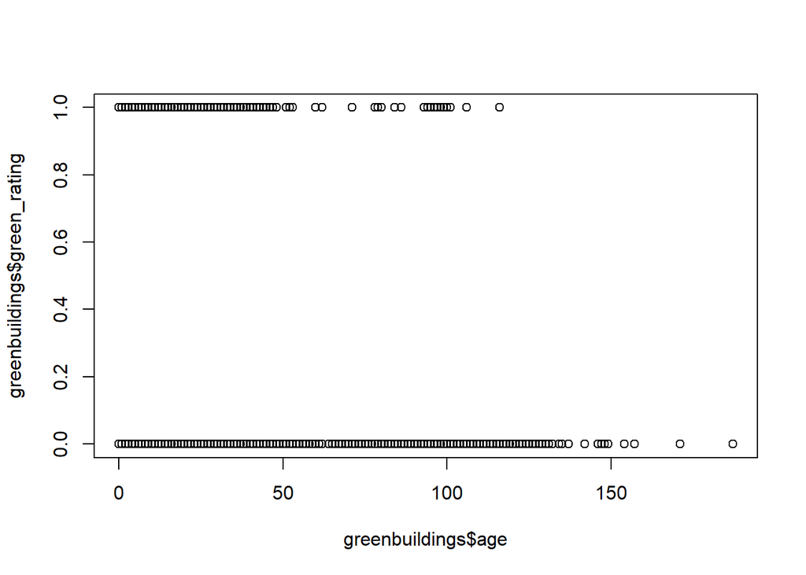

```r
plot(greenbuildings$age, greenbuildings$green_rating)
```

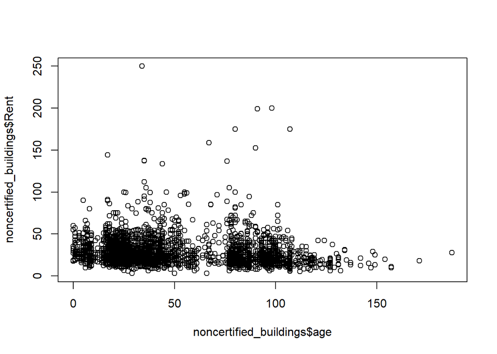

```r
plot(noncertified_buildings$age, noncertified_buildings$Rent)
```

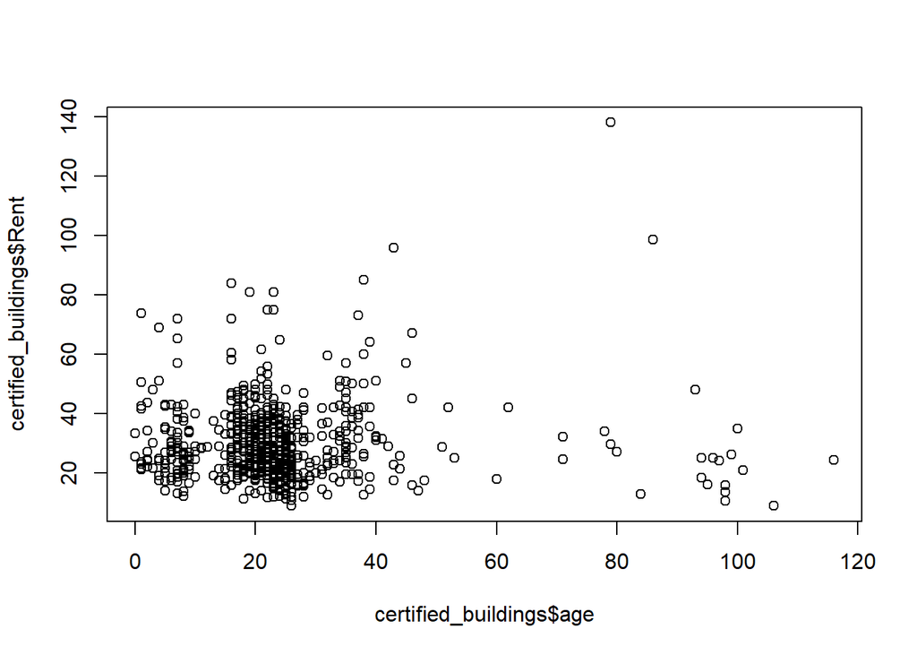

```r
plot(certified_buildings$age, certified_buildings$Rent)
```

There is a slight negative correlation between the age of a non-certified green building and its rent. This should impact the analysis, as the rent of newer buildings is more relevant than that of older buildings. Older buildings are both more likely to not be green, and to have lower rent.

# Stock Portfolio

```r
library(quantmod) #for getting yahoo stock data
# Import the specified stocks
mystocks = c("VNQ", "EEM", "SPY", "TLT", "LQD")
getSymbols(mystocks) #gets stocks from yahoo
```

[output not shown]

[output not shown]

```
## [1] "VNQ" "EEM" "SPY" "TLT" "LQD"
```

```r
# A chunk of code for adjusting all stocks
# creates a new object addind 'a' to the end
# For example, WMT becomes WMTa, etc
for(ticker in mystocks) {
    expr = paste0(ticker, "a = adjustOHLC(", ticker, ")")
    eval(parse(text=expr))
}

# Combine close to close changes in a single matrix
all_returns = cbind(ClCl(SPYa), ClCl(TLTa), ClCl(LQDa), ClCl(EEMa), ClCl(VNQa))

all_returns = as.matrix(na.omit(all_returns))

head(all_returns)
```

```
##                ClCl.SPYa    ClCl.TLTa     ClCl.LQDa    ClCl.EEMa
## 2007-01-04  0.0021221123  0.006063328  0.0075152938 -0.013809353
## 2007-01-05 -0.0079763183 -0.004352668 -0.0006526807 -0.029238205
## 2007-01-08  0.0046250821  0.001793566 -0.0002798843  0.007257535
## 2007-01-09 -0.0008498831  0.000000000  0.0001866169 -0.022336235
## 2007-01-10  0.0033315799 -0.004475797 -0.0013063264 -0.002303160
## 2007-01-11  0.0043804651 -0.005844712 -0.0030832664  0.012650112
##               ClCl.VNQa
## 2007-01-04  0.001296655
## 2007-01-05 -0.018518518
## 2007-01-08  0.001451392
## 2007-01-09  0.012648208
## 2007-01-10  0.012880523
## 2007-01-11  0.012973706
```

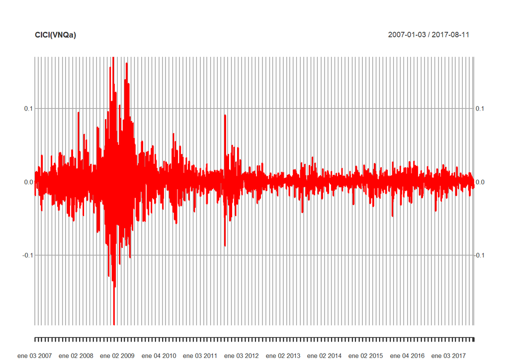

```r
#compare the risk of each of the five stocks
plot(ClCl(VNQa), col="red")
```

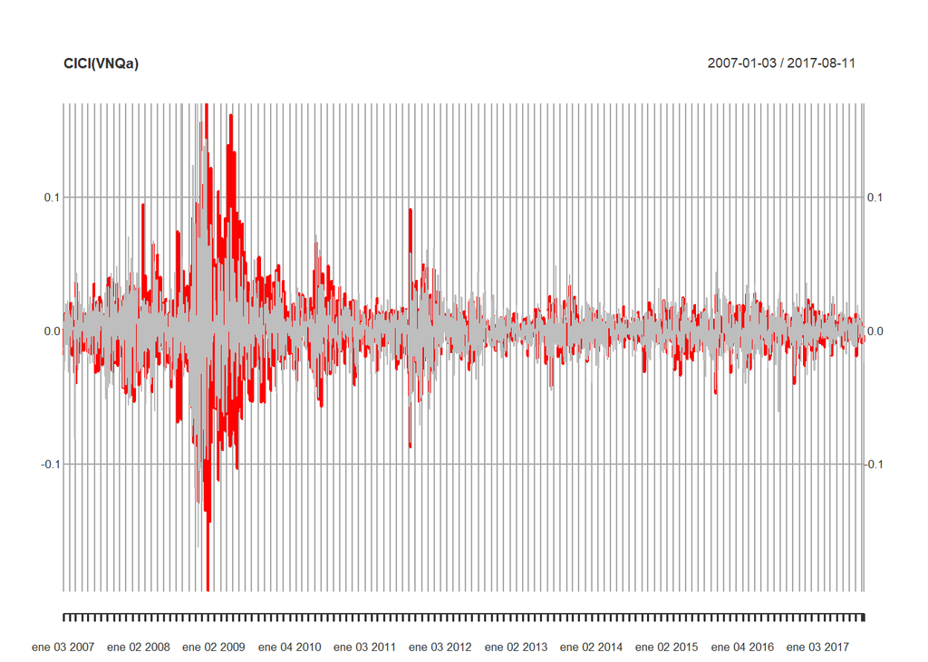

```r
lines(ClCl(EEMa), col="gray")
```

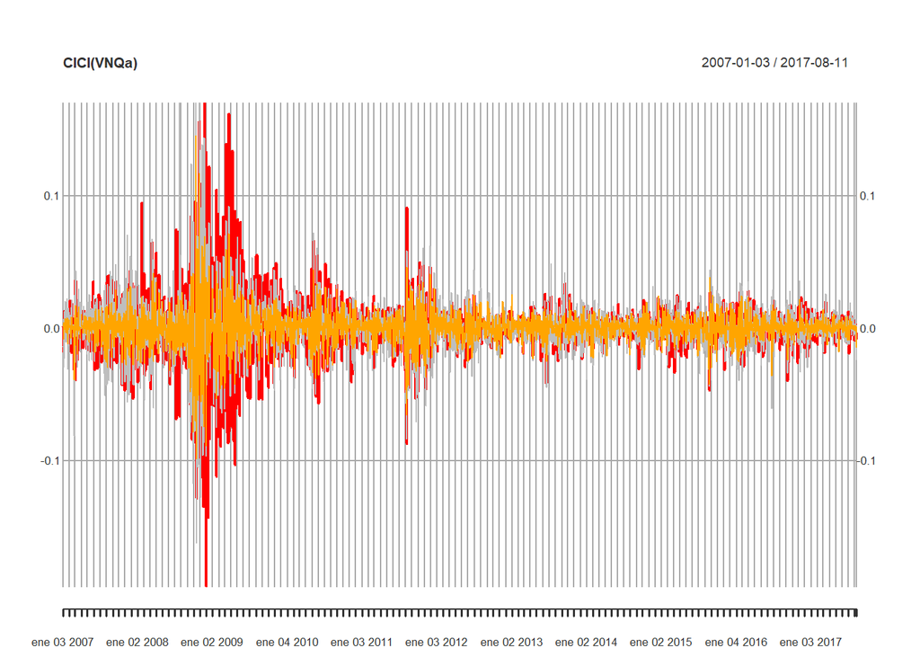

```r
lines(ClCl(SPYa), col="orange")
```

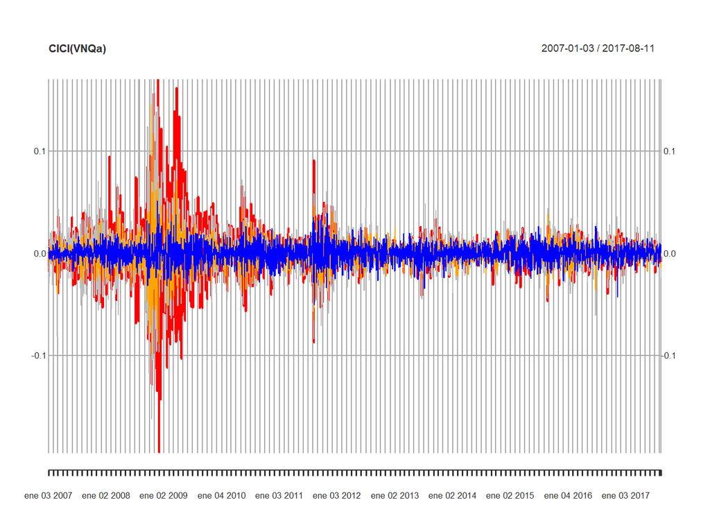

```r
lines(ClCl(TLTa), col="blue")
```

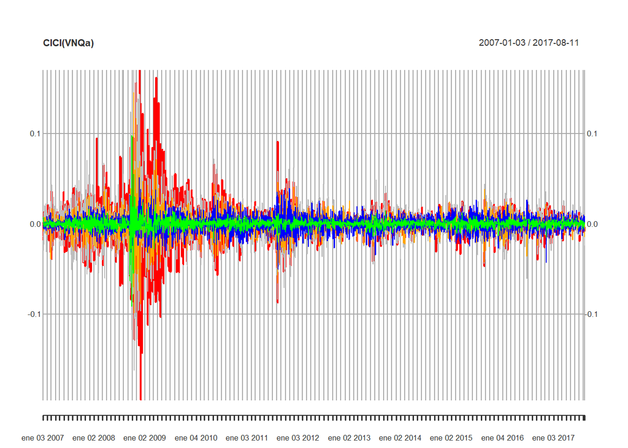

```r
lines(ClCl(LQDa), col="green")
```

```r
median(na.omit(ClCl(VNQa)))
```

```
## [1] 0.0006913412
```

```r
median(na.omit(ClCl(EEMa)))
```

```
## [1] 0.0008560787
```

```r
median(na.omit(ClCl(SPYa)))
```

```
## [1] 0.0006295127
```

```r
median(na.omit(ClCl(TLTa)))
```

```
## [1] 0.0005947324
```

```r
median(na.omit(ClCl(LQDa)))
```

```
## [1] 0.0004315812
```

```r
sd(na.omit(ClCl(VNQa)))
```

```
## [1] 0.02198417
```

```r
sd(na.omit(ClCl(EEMa)))
```

```
## [1] 0.04194861
```

```r
sd(na.omit(ClCl(SPYa)))
```

```
## [1] 0.01279036
```

```r
sd(na.omit(ClCl(TLTa)))
```

```
## [1] 0.009399709
```

```r
sd(na.omit(ClCl(LQDa)))
```

```
## [1] 0.005404678
```

### standard portfolio

```r
set.seed(12345)
# imulate many different possible scenarios
initial_wealth = 100000
sim1 = foreach(i=1:5000, .combine='rbind') %do% {
    total_wealth = initial_wealth
    weights = c(0.2, 0.2, 0.2, 0.2, 0.2)
    holdings = weights * total_wealth
    n_days = 20
    wealthtracker = rep(0, n_days)
    for(today in 1:n_days) {
        return.today = resample(all_returns, 1, orig.ids=FALSE)
        holdings = holdings + holdings*return.today
        total_wealth = sum(holdings)
        wealthtracker[today] = total_wealth
        #redistribute wealth among holdings
        holdings = weights * total_wealth
    }
    wealthtracker
}

head(sim1)
```

```
##              [,1]     [,2]     [,3]     [,4]     [,5]     [,6]     [,7]
## result.1 100120.7 100385.4 100462.3 100802.7 101958.4 100724.5 102132.3
## result.2 101660.5 100671.4 100681.6 100840.4 100730.4 100941.2 100825.9
## result.3 100032.1 100605.0 100066.9 100431.6 101860.0 100845.4 100663.9
## result.4 100457.0 100276.7 100097.0 100203.3 100176.2 100186.6 100072.3
## result.5 101192.8 102090.5 102573.5 102970.0 105038.2 105181.5 106023.0
## result.6 100051.3 100424.3 100884.1 101049.3 100921.1 100576.4 100439.4
##               [,8]      [,9]     [,10]     [,11]     [,12]     [,13]
## result.1 102014.02 101429.85 101190.09 100581.90 101508.58 102006.17
## result.2 100758.62 102904.82 103088.53 102565.01 102709.48 104940.71
## result.3  99349.14  97443.06  96492.05  96830.45  97066.18  95109.01
## result.4  98937.80  98970.72  98432.76  98321.82  98273.74  97299.94
## result.5 105837.14 106132.22 107165.90 107349.87 107211.05 106987.04
## result.6 101019.75  98960.05 100010.49  97183.52  97057.83  97414.77
##              [,14]     [,15]     [,16]     [,17]     [,18]     [,19]
## result.1 101795.00 102870.72 102474.07 103388.58 103066.76 108840.66
## result.2 105414.35 105318.39 106267.65 105961.40 106190.54 106586.49
## result.3  92846.04  92028.21  91805.43  91513.83  91567.09  92897.76
## result.4  97008.36  96320.27  96452.08  96639.16  96249.35  95684.92
## result.5 107044.51 107320.92 107285.00 107417.91 106689.36 107986.37
## result.6  97531.60  97028.34  97272.99  97530.10  97420.04  96624.78
##              [,20]
## result.1 108852.50
## result.2 107938.20
## result.3  93006.32
## result.4  96008.98
## result.5 107950.32
## result.6  95879.28
```

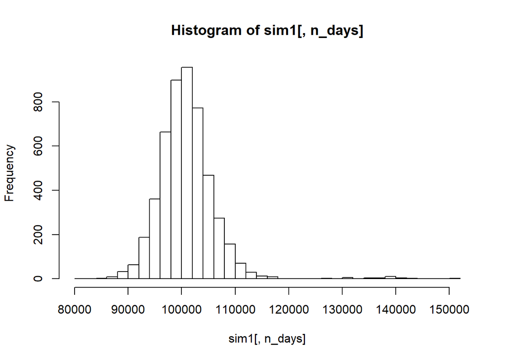

```r
hist(sim1[,n_days], 25)
```

```r
# Profit/loss
mean(sim1[,n_days])
```

```
## [1] 100950.4
```

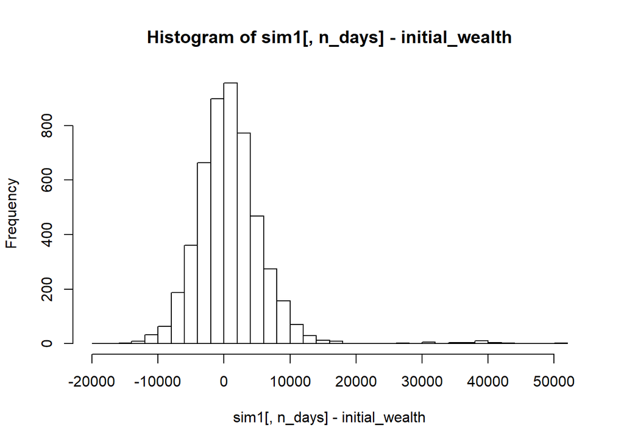

```r
hist(sim1[,n_days]- initial_wealth, breaks=30)
```

```r
# the value at risk is the specified quantile in the profit and loss distribution
# Calculate 5% value at risk
# 5% of the time, what is the amoutn of money that I am losing?
quantile(sim1[,n_days], 0.05) - initial_wealth
```

```
##        5%
## -6363.609
```

```r
# 5% of the time I am losing more than ^ this amount
```

### safe portfolio

```r
head(all_returns)
```

```
##                ClCl.SPYa    ClCl.TLTa     ClCl.LQDa    ClCl.EEMa
## 2007-01-04  0.0021221123  0.006063328  0.0075152938 -0.013809353
## 2007-01-05 -0.0079763183 -0.004352668 -0.0006526807 -0.029238205
## 2007-01-08  0.0046250821  0.001793566 -0.0002798843  0.007257535
## 2007-01-09 -0.0008498831  0.000000000  0.0001866169 -0.022336235
## 2007-01-10  0.0033315799 -0.004475797 -0.0013063264 -0.002303160
## 2007-01-11  0.0043804651 -0.005844712 -0.0030832664  0.012650112
##               ClCl.VNQa
## 2007-01-04  0.001296655
## 2007-01-05 -0.018518518
## 2007-01-08  0.001451392
## 2007-01-09  0.012648208
## 2007-01-10  0.012880523
## 2007-01-11  0.012973706
```

```r
initial_wealth = 100000
sim2 = foreach(i=1:5000, .combine='rbind') %do% {
    total_wealth = initial_wealth
    weights = c(.34, .33, 0.33, 0, 0)
    holdings = weights * total_wealth
    n_days = 20
    wealthtracker = rep(0, n_days)
    for(today in 1:n_days) {
        return.today = resample(all_returns, 1, orig.ids=FALSE)
        holdings = holdings + holdings*return.today
        total_wealth = sum(holdings)
        wealthtracker[today] = total_wealth
        #redistribute wealth among holdings
        holdings = weights * total_wealth
    }
    wealthtracker
}

head(sim2)
```

```
##               [,1]      [,2]      [,3]      [,4]      [,5]      [,6]
## result.1  99767.86 100236.57 100934.83 101067.96 100981.56 101436.09
## result.2 100007.84  99231.88  99638.57 100051.40 100272.49 100163.29
## result.3  99930.07  99285.30  99255.14  98605.38  98677.27  99092.76
## result.4 100055.89 100476.83 101767.81 101238.07 101145.38 101365.18
## result.5  99845.17 100258.86 101008.43 101464.49 100926.43 101352.35
## result.6  99436.76 100050.20 101395.37 100710.56 100707.02 100792.27
##               [,7]      [,8]      [,9]     [,10]     [,11]     [,12]
## result.1 101662.46 101149.80 100038.13 100036.17  99510.08  99896.46
## result.2  99875.49  99560.25  99791.61  99712.33  99942.04 100009.78
## result.3  98350.37  98656.21  99503.23  99516.21  99420.83  99408.13
## result.4 101979.16 102395.96 102363.26 102259.41 101703.96 102192.55
## result.5 101611.84 101818.63 102130.36 101337.93 101703.27 101877.64
## result.6 100884.96 101999.92 102590.80 102240.97 101374.48 101487.71
##              [,13]     [,14]     [,15]     [,16]     [,17]     [,18]
## result.1  99815.01 100298.15 100679.30 100260.51 100480.24 100559.89
## result.2 100122.11 100332.96  99444.85  99722.00  99543.00  99702.72
## result.3  98860.83  99010.44  98710.22  98818.94  98824.08  99541.96
## result.4 105538.69 105639.29 105158.36 104858.36 103636.18 103061.34
## result.5 102057.51 102159.41 102512.49 102650.44 102543.56 102414.14
## result.6 101631.31 101290.72 101187.96 101368.22 101262.83 101415.72
##              [,19]     [,20]
## result.1 100631.56 100663.40
## result.2 101440.39 100882.44
## result.3  99471.72  99466.85
## result.4 103393.65 103222.53
## result.5 102808.15 102791.42
## result.6 100995.59 100854.95
```

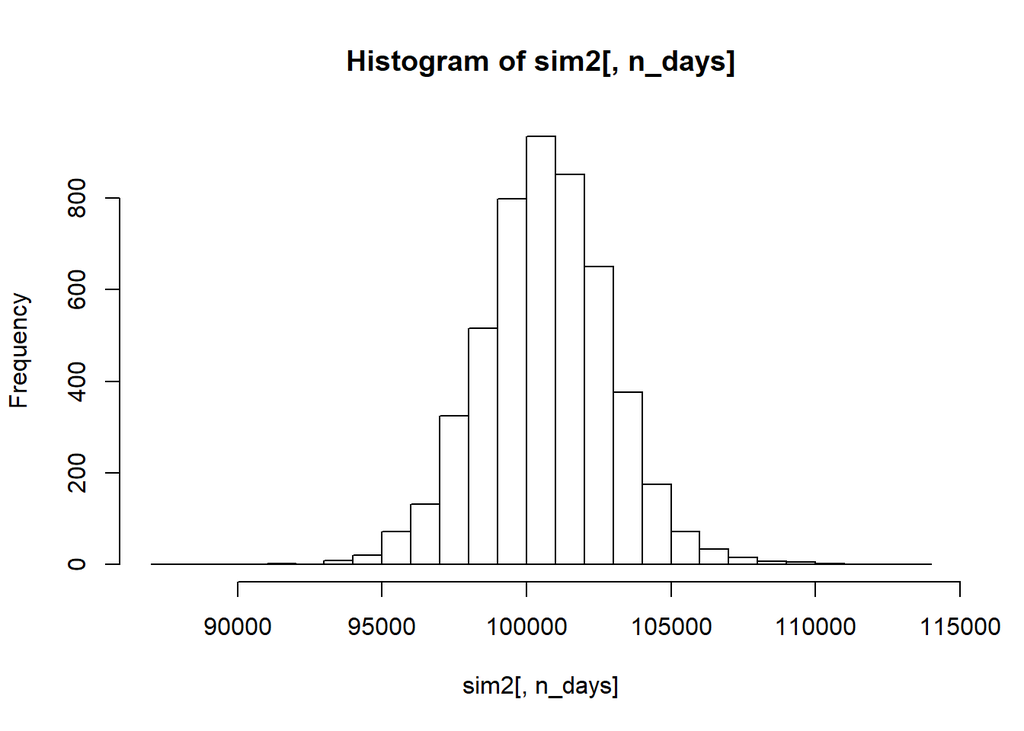

```r
hist(sim2[,n_days], 25)
```

```r
# Profit/loss
mean(sim2[,n_days])
```

```
## [1] 100663.4
```

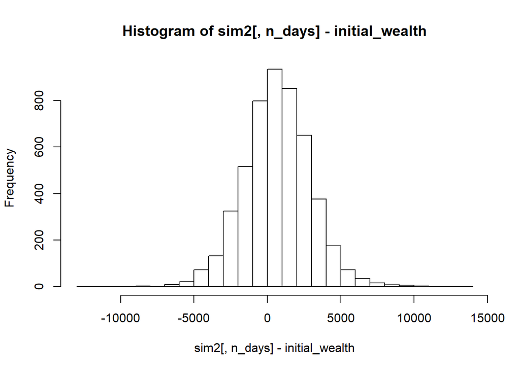

```r
hist(sim2[,n_days]- initial_wealth, breaks=30)
```

```r
# the value at risk is the specified quantile in the profit and loss distribution
# Calculate 5% value at risk
# 5% of the time, what is the amoutn of money that I am losing?
quantile(sim2[,n_days], 0.05) - initial_wealth
```

```
##        5%
## -2945.199
```

```r
# 5% of the time I am losing more than ^ this amount
```

### aggresive portfolio

```r
head(all_returns)
```

```
##                ClCl.SPYa    ClCl.TLTa     ClCl.LQDa    ClCl.EEMa
## 2007-01-04  0.0021221123  0.006063328  0.0075152938 -0.013809353
## 2007-01-05 -0.0079763183 -0.004352668 -0.0006526807 -0.029238205
## 2007-01-08  0.0046250821  0.001793566 -0.0002798843  0.007257535
## 2007-01-09 -0.0008498831  0.000000000  0.0001866169 -0.022336235
## 2007-01-10  0.0033315799 -0.004475797 -0.0013063264 -0.002303160
## 2007-01-11  0.0043804651 -0.005844712 -0.0030832664  0.012650112
##               ClCl.VNQa
## 2007-01-04  0.001296655
## 2007-01-05 -0.018518518
## 2007-01-08  0.001451392
## 2007-01-09  0.012648208
## 2007-01-10  0.012880523
## 2007-01-11  0.012973706
```

```r
initial_wealth = 100000
sim3 = foreach(i=1:5000, .combine='rbind') %do% {
    total_wealth = initial_wealth
    weights = c(0, 0, 0, .5, .5)
    holdings = weights * total_wealth
    n_days = 20
    wealthtracker = rep(0, n_days)
    for(today in 1:n_days) {
        return.today = resample(all_returns, 1, orig.ids=FALSE)
        holdings = holdings + holdings*return.today
        total_wealth = sum(holdings)
        wealthtracker[today] = total_wealth
        #redistribute wealth among holdings
        holdings = weights * total_wealth
    }
    wealthtracker
}

head(sim3)
```

```
##               [,1]     [,2]      [,3]      [,4]      [,5]      [,6]
## result.1 100960.72 100412.9 100915.50  97814.34  98550.51  98885.04
## result.2 101374.52 100813.8 100571.60 101513.78 101535.96 101517.82
## result.3  99965.21 118243.8 118884.54 119602.18 120028.68 120168.06
## result.4 105769.97 109152.1 108672.05 107235.84 108021.51 109260.25
## result.5 100439.98  99412.4  99525.55  98226.42  98735.38  98569.57
## result.6 100136.20 100459.7 100599.05  99990.78 101152.29  99706.88
##               [,7]      [,8]      [,9]     [,10]     [,11]     [,12]
## result.1  98371.58  90954.35  89577.96  76524.95  75612.39  76549.93
## result.2 100709.67 101404.42 100066.64 100221.38 101505.40 101074.20
## result.3 120368.82 120701.22 122716.43 122765.63 122723.32 124493.82
## result.4 109547.38 104366.62 103227.43 102480.88 102376.45 103056.21
## result.5  97592.47  97551.72  99081.94  98304.73  99129.45  99984.80
## result.6 101268.34 101196.24  98717.86  98753.94  97776.90  97204.64
##              [,13]     [,14]     [,15]     [,16]     [,17]     [,18]
## result.1  76644.97  77249.02  77511.99  77551.40  78403.29  79457.04
## result.2 101518.90 100277.68 100405.31 100783.31 100245.87  99710.16
## result.3 123636.00 123409.06 123690.69 125693.60 123542.21 122348.21
## result.4 102919.86 102931.71 102767.91 102835.99 102782.89  95033.04
## result.5  92340.65  87528.53  87589.21  86703.04  84823.86  82919.08
## result.6  96677.73  91551.41  90170.25  91203.04  90045.20  90134.66
##              [,19]     [,20]
## result.1  82558.68  81555.28
## result.2 102689.72 106297.84
## result.3 122211.50 121456.83
## result.4  95506.89  96706.34
## result.5  82281.25  83057.70
## result.6  86793.55  85763.91
```

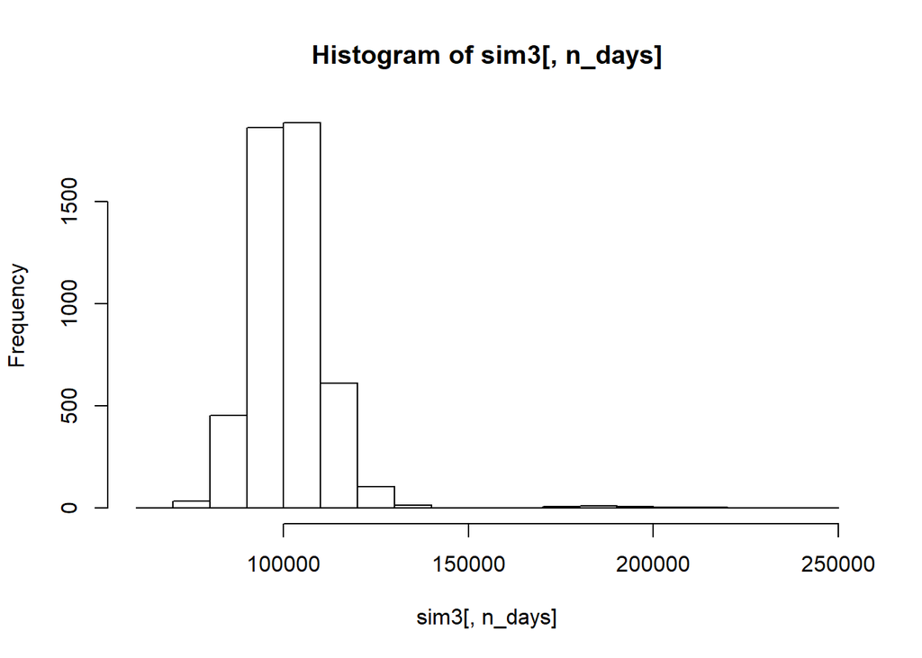

```r
hist(sim3[,n_days], 25)
```

```r
# Profit/loss
mean(sim3[,n_days])
```

```
## [1] 101597.9
```

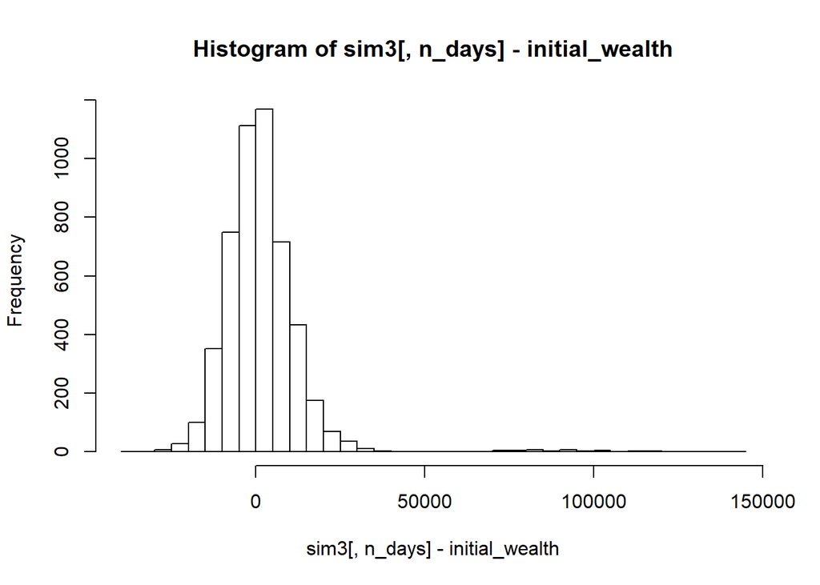

```r
hist(sim3[,n_days]- initial_wealth, breaks=30)
```

```r
# the value at risk is the specified quantile in the profit and loss distribution
# Calculate 5% value at risk
# 5% of the time, what is the amoutn of money that I am losing?
quantile(sim3[,n_days], 0.05) - initial_wealth
```

```
##        5%
## -12780.84
```

```r
# 5% of the time I am losing more than ^ this amount
# bozzle 2 (sic) says that every bank must calculate this for every two weeks
```

### Solution

#### comparing the three portfolios

Expected results after 20 trading days:

#### Standard:

Expected Profit: 950.4 5% Risk: -6363.609

#### Safe:

Expected Profit: 663.4 5% Risk: -2945.199

#### Aggressive:

Expected Profit: 1597.9 5% Risk: -12780.84

# Market Segmentation

```r
library(corrplot)
socialmarketing <- read.csv("https://raw.githubusercontent.com/jgscott/STA380/master/data/social_marketing.csv")

head(socialmarketing)
```

```
##           X chatter current_events travel photo_sharing uncategorized
## 1 hmjoe4g3k       2              0      2             2             2
## 2 clk1m5w8s       3              3      2             1             1
## 3 jcsovtak3       6              3      4             3             1
## 4 3oeb4hiln       1              5      2             2             0
## 5 fd75x1vgk       5              2      0             6             1
## 6 h6nvj91yp       6              4      2             7             0
##   tv_film sports_fandom politics food family home_and_garden music news
## 1       1             1        0    4      1               2     0    0
## 2       1             4        1    2      2               1     0    0
## 3       5             0        2    1      1               1     1    1
## 4       1             0        1    0      1               0     0    0
## 5       0             0        2    0      1               0     0    0
## 6       1             1        0    2      1               1     1    0
##   online_gaming shopping health_nutrition college_uni sports_playing
```

[output cut: 27 more lines]

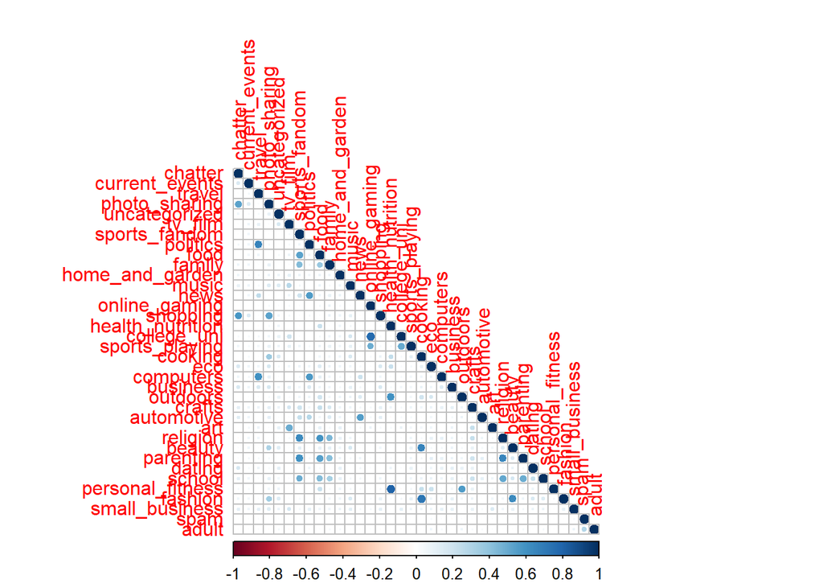

```r
#remove user hash
social_mkt = socialmarketing[,-1]

corr_mat = cor(social_mkt)
corrplot(corr_mat, type="lower")
```

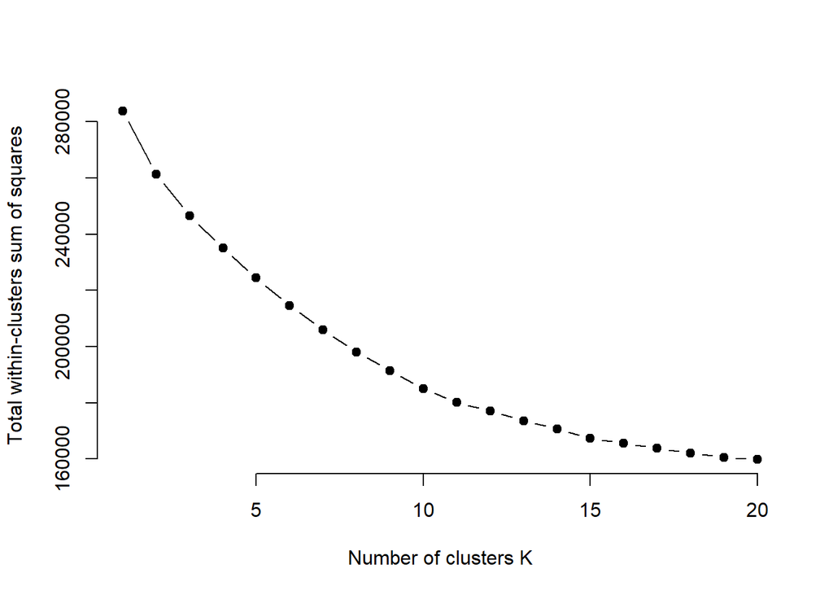

```r
#scale values
social_scaled <- scale(social_mkt, center=TRUE, scale=TRUE)

k.max <-20
wss <- sapply(1:k.max,
        function(k){kmeans(social_scaled, k, nstart=10, iter.max = 50 )$tot.withinss})
plot(1:k.max, wss,
       type="b", pch = 19, frame = FALSE,
       xlab="Number of clusters K",
       ylab="Total within-clusters sum of squares")
```

#### From the elbow plot it looks like 10 is a good number for K.

```r
#creating the clusters
set.seed(333)
clust = kmeans(social_scaled, centers=10, nstart=50)
```

```r
#unscale
mu=attr(social_scaled,"scaled:center")
sigma=attr(social_scaled,"scaled:scale")
```

#### Cluster 1

```r
rbind(clust$center[1,],(clust$center[1,]*sigma + mu))
```

```
##       chatter current_events    travel photo_sharing uncategorized
## [1,] 1.513382      0.3256537 -0.193755      1.109426    0.07767799
## [2,] 9.739673      1.9394813  1.142171      5.727185    0.88568684
##         tv_film sports_fandom   politics       food      family
## [1,] -0.1402417    -0.1953159 -0.1451378 -0.2941994 -0.04434752
## [2,]  0.8376561     1.1719500  1.3487032  0.8751201  0.81364073
##      home_and_garden     music       news online_gaming shopping
## [1,]       0.1068882 0.1453779 -0.2683960    -0.1538406 1.394400
## [2,]       0.5994236 0.8290106  0.6416907     0.7953890 3.911623
##      health_nutrition college_uni sports_playing    cooking       eco
## [1,]       -0.2231603  -0.0931745    -0.04961449 -0.2249365 0.2891472
## [2,]        1.5638809   1.2795389     0.59077810  1.2267051 0.7348703
##       computers  business   outdoors     crafts automotive        art
## [1,] -0.0315080 0.3404767 -0.2364907 0.07878143 0.08094008 -0.1989719
## [2,]  0.6119116 0.6589817  0.4966378 0.58021134 0.94044188  0.4005764
##        religion     beauty  parenting    dating     school
## [1,] -0.2605274 -0.1765564 -0.1940520 0.3120553 0.09848665
## [2,]  0.5965418  0.4707012  0.6272815 1.2670509 0.88472622
##      personal_fitness     fashion small_business          spam       adult
## [1,]       -0.1825223 -0.06590077      0.1660851 -7.768727e-02 -0.02694189
## [2,]        1.0230548  0.87608069      0.4390010  5.117434e-17  0.35446686
```

#### Cluster 2

```r
rbind(clust$center[2,],(clust$center[2,]*sigma + mu))
```

```
##         chatter current_events     travel photo_sharing uncategorized
## [1,] -0.1306213       0.103646 -0.1016881   -0.09834462    -0.1056977
## [2,]  3.9377778       1.657778  1.3525926    2.42814815     0.7140741
##          tv_film sports_fandom   politics     food   family
## [1,] -0.09774549      2.093104 -0.2244997 1.852894 1.515921
## [2,]  0.90814815      6.117037  1.1081481 4.687407 2.580741
##      home_and_garden      music       news online_gaming    shopping
## [1,]       0.1579454 0.02372246 -0.1112347   -0.07605153 -0.02278803
## [2,]       0.6370370 0.70370370  0.9718519    1.00444444  1.34814815
##      health_nutrition college_uni sports_playing     cooking       eco
## [1,]       -0.1409894  -0.1293217      0.1041118 -0.09752941 0.1851419
## [2,]        1.9333333   1.1748148      0.7407407  1.66370370 0.6548148
##       computers  business    outdoors    crafts automotive        art
## [1,] 0.09153665 0.1033711 -0.06651367 0.6978867  0.1169447 -0.0247743
## [2,] 0.75703704 0.4948148  0.70222222 1.0859259  0.9896296  0.6844444
##      religion    beauty parenting    dating   school personal_fitness
## [1,] 2.294451 0.3235657  2.168508 0.0242455 1.685383      -0.08924585
## [2,] 5.488889 1.1348148  4.207407 0.7540741 2.770370       1.24740741
##         fashion small_business          spam        adult
## [1,] 0.01321708     0.09100854 -7.768727e-02 -0.005100812
## [2,] 1.02074074     0.39259259 -2.341877e-17  0.394074074
```

#### Cluster 3

```r
rbind(clust$center[3,],(clust$center[3,]*sigma + mu))
```

```
##        chatter current_events     travel photo_sharing uncategorized
## [1,] -0.366770      -0.199873 -0.2215765    -0.4226548    -0.1738752
## [2,]  3.104379       1.272645  1.0785843     1.5422915     0.6502699
##         tv_film sports_fandom   politics       food     family
## [1,] -0.2233726    -0.3247186 -0.3018386 -0.3627248 -0.3040637
## [2,]  0.6997600     0.8923215  0.8737253  0.7534493  0.5194961
##      home_and_garden      music      news online_gaming   shopping
## [1,]      -0.2002938 -0.2308292 -0.309572    -0.2335087 -0.3943417
## [2,]       0.3731254  0.4415117  0.555189     0.5812837  0.6760648
##      health_nutrition college_uni sports_playing    cooking        eco
## [1,]       -0.3148191  -0.2570594     -0.2635057 -0.3268859 -0.2723922
## [2,]        1.1517696   0.8047391      0.3821236  0.8770246  0.3026395
##       computers   business   outdoors     crafts automotive        art
## [1,] -0.2555789 -0.2413332 -0.3269553 -0.2911370 -0.3106147 -0.2369843
## [2,]  0.3476305  0.2561488  0.3872226  0.2780444  0.4055189  0.3386323
##        religion     beauty  parenting     dating     school
## [1,] -0.2999805 -0.2733027 -0.3217895 -0.1719873 -0.3201961
## [2,]  0.5209958  0.3422316  0.4337133  0.4043191  0.3872226
##      personal_fitness    fashion small_business          spam       adult
## [1,]       -0.3325225 -0.2924214     -0.2039613 -7.768727e-02 -0.01351021
## [2,]        0.6622675  0.4619076      0.2102579 -2.853620e-16  0.37882424
```

#### Cluster 4

```r
rbind(clust$center[4,],(clust$center[4,]*sigma + mu))
```

```
##          chatter current_events   travel photo_sharing uncategorized
## [1,] -0.07726621      0.1136621 3.265636     -0.110328   -0.08797596
## [2,]  4.12607450      1.6704871 9.048711      2.395415    0.73065903
##          tv_film sports_fandom politics      food      family
## [1,] -0.07173772    -0.2085897  3.11929 0.1569816 -0.09231701
## [2,]  0.95128940     1.1432665 11.24355 1.6762178  0.75931232
##      home_and_garden      music     news online_gaming    shopping
## [1,]      0.05166238 -0.0419082 1.140618    -0.1704632 -0.07586007
## [2,]      0.55873926  0.6361032 3.601719     0.7507163  1.25214900
##      health_nutrition college_uni sports_playing    cooking       eco
## [1,]       -0.1694973 -0.04922176     0.04384399 -0.1866089 0.1608323
## [2,]        1.8051576  1.40687679     0.68194842  1.3581662 0.6361032
##      computers  business    outdoors    crafts automotive        art
## [1,]  2.911536 0.5598746 -0.03826403 0.2033299 -0.1313440 -0.1616973
## [2,]  4.083095 0.8108883  0.73638968 0.6819484  0.6504298  0.4613181
##       religion     beauty  parenting   dating     school personal_fitness
## [1,] 0.1162737 -0.1771492 0.02354578 0.305302 -0.1059236        -0.148030
## [2,] 1.3180516  0.4699140 0.95702006 1.255014  0.6418338         1.106017
##         fashion small_business          spam      adult
## [1,] -0.1705090      0.4015086 -7.768727e-02 -0.1434066
## [2,]  0.6848138      0.5845272  5.030698e-17  0.1432665
```

#### Cluster 5

```r
rbind(clust$center[5,],(clust$center[5,]*sigma + mu))
```

```
##          chatter current_events     travel photo_sharing uncategorized
## [1,] -0.06873643      0.0720734 -0.1866069    -0.2209537   -0.09408515
## [2,]  4.15617716      1.6177156  1.1585082     2.0932401    0.72494172
##        tv_film sports_fandom politics       food    family home_and_garden
## [1,] -0.011457     0.6679035 1.225577 -0.1542867 0.2354565       0.1601955
## [2,]  1.051282     3.0372960 5.503497  1.1235431 1.1305361       0.6386946
##            music     news online_gaming   shopping health_nutrition
## [1,] -0.08917992 2.663931    -0.1219407 -0.1881958       -0.2428119
## [2,]  0.58741259 6.801865     0.8811189  1.0489510        1.4755245
##      college_uni sports_playing    cooking         eco  computers
## [1,]  -0.1944894    -0.08412803 -0.2346252 -0.09623969 -0.1866707
## [2,]   0.9860140     0.55710956  1.1934732  0.43822844  0.4289044
##        business  outdoors     crafts automotive        art   religion
## [1,] -0.1231226 0.3107434 -0.1606708   2.590075 -0.1615621 -0.1788637
## [2,]  0.3379953 1.1585082  0.3846154   4.368298  0.4615385  0.7529138
##          beauty  parenting      dating     school personal_fitness
## [1,] -0.1764350 0.04114091 -0.03394992 0.01502133       -0.2299037
## [2,]  0.4708625 0.98368298  0.65034965 0.78554779        0.9090909
##         fashion small_business          spam      adult
## [1,] -0.2148557     -0.1556956 -7.768727e-02 -0.1092935
## [2,]  0.6037296      0.2400932  5.377643e-17  0.2051282
```

#### Cluster 6

```r
rbind(clust$center[6,],(clust$center[6,]*sigma + mu))
```

```
##         chatter current_events     travel photo_sharing uncategorized
## [1,] -0.1399589    -0.02121086 -0.1555606    -0.1171457     0.1663911
## [2,]  3.9048240     1.49934811  1.2294654     2.3767927     0.9687093
##         tv_film sports_fandom   politics     food      family
## [1,] -0.1461227    -0.2018838 -0.1991002 0.449481 -0.08816419
## [2,]  0.8279009     1.1577575  1.1851369 2.195567  0.76401565
##      home_and_garden        music        news online_gaming    shopping
## [1,]       0.1586402 -0.003796723 -0.07052867    -0.1150606 -0.07254324
## [2,]       0.6375489  0.675358540  1.05736636     0.8996089  1.25814863
##      health_nutrition college_uni sports_playing   cooking       eco
## [1,]         2.216857  -0.2135130    -0.02572691 0.4148461 0.5573723
## [2,]        12.534550   0.9308996     0.61408083 3.4211213 0.9413299
##        computers   business outdoors     crafts automotive         art
## [1,] -0.08272858 0.04966108 1.731959 0.06757337 -0.1770378 -0.07675421
## [2,]  0.55149935 0.45762712 2.877445 0.57105606  0.5880052  0.59973924
##        religion     beauty   parenting    dating     school
## [1,] -0.1648952 -0.2060388 -0.09177444 0.1907526 -0.1676823
## [2,]  0.7796610  0.4315515  0.78226858 1.0508475  0.5684485
##      personal_fitness     fashion small_business          spam      adult
## [1,]         2.153918 -0.09795591     -0.1201591 -7.768727e-02 0.01772269
## [2,]         6.642764  0.81747066      0.2620600 -4.076600e-17 0.43546284
```

#### Cluster 7

```r
rbind(clust$center[7,],(clust$center[7,]*sigma + mu))
```

```
##          chatter current_events      travel photo_sharing uncategorized
## [1,] -0.04319508      0.1775698 -0.05423302      1.241674     0.4990187
## [2,]  4.24631579      1.7515789  1.46105263      6.088421     1.2800000
##         tv_film sports_fandom   politics       food     family
## [1,] -0.1362904    -0.2057172 -0.1275198 -0.2037098 0.02911547
## [2,]  0.8442105     1.1494737  1.4021053  1.0357895 0.89684211
##      home_and_garden     music        news online_gaming  shopping
## [1,]       0.1419633 0.5525667 -0.07578889   -0.02286982 0.2025719
## [2,]       0.6252632 1.2484211  1.04631579    1.14736842 1.7557895
##      health_nutrition college_uni sports_playing   cooking           eco
## [1,]      -0.06622745 -0.01816877      0.2015461  2.823952 -0.0009452388
## [2,]       2.26947368  1.49684211      0.8357895 11.684211  0.5115789474
##       computers  business    outdoors     crafts automotive          art
## [1,] 0.05656488 0.2279240 0.007366432 0.08238866 0.01204133 0.0009203335
## [2,] 0.71578947 0.5810526 0.791578947 0.58315789 0.84631579 0.7263157895
##        religion   beauty   parenting     dating    school personal_fitness
## [1,] -0.1212898 2.638198 -0.05784476 0.04883143 0.1724649      -0.04418512
## [2,]  0.8631579 4.208421  0.83368421 0.79789474 0.9726316       1.35578947
##       fashion small_business          spam        adult
## [1,] 2.728426      0.1642956 -7.768727e-02 0.0004888515
## [2,] 5.985263      0.4378947  3.295975e-17 0.4042105263
```

#### Cluster 8

```r
rbind(clust$center[8,],(clust$center[8,]*sigma + mu))
```

```
##        chatter current_events   travel photo_sharing uncategorized
## [1,] 0.0720588      0.2768471 0.288727   -0.09071828     0.1125985
## [2,] 4.6530612      1.8775510 2.244898    2.44897959     0.9183673
##        tv_film sports_fandom  politics       food      family
## [1,] -0.116191     0.1406567 0.1505274 0.04049422 -0.05999555
## [2,]  0.877551     1.8979592 2.2448980 1.46938776  0.79591837
##      home_and_garden      music          news online_gaming   shopping
## [1,]       0.2351019 0.01418264 -0.0006901999    0.08935906 -0.2378226
## [2,]       0.6938776 0.69387755  1.2040816327    1.44897959  0.9591837
##      health_nutrition college_uni sports_playing     cooking       eco
## [1,]       0.05086059   0.1273275     -0.1112904 -0.05898219 0.4479995
## [2,]       2.79591837   1.9183673      0.5306122  1.79591837 0.8571429
##      computers   business  outdoors    crafts automotive       art
## [1,] 0.2975329 -0.3460090 0.2978031 0.2179337  0.1245356 0.3316754
## [2,] 1.0000000  0.1836735 1.1428571 0.6938776  1.0000000 1.2653061
##       religion     beauty parenting       dating     school
## [1,] 0.1207018 -0.1007020 0.1865841 -0.009528244 0.09244824
## [2,] 1.3265306  0.5714286 1.2040816  0.693877551 0.87755102
##      personal_fitness     fashion small_business      spam    adult
## [1,]        0.1218324 -0.02044987      0.3142883 12.418865 3.750222
## [2,]        1.7551020  0.95918367      0.5306122  1.040816 7.204082
```

#### Cluster 9

```r
rbind(clust$center[9,],(clust$center[9,]*sigma + mu))
```

```
##          chatter current_events      travel photo_sharing uncategorized
## [1,] -0.09679843    -0.09275107 -0.03344187    -0.0218321   -0.03830597
## [2,]  4.05714286     1.40857143  1.50857143     2.6371429    0.77714286
##         tv_film sports_fandom   politics        food    family
## [1,] 0.09886703    -0.1373809 -0.1762872 -0.09835267 0.2034491
## [2,] 1.23428571     1.2971429  1.2542857  1.22285714 1.0942857
##      home_and_garden       music       news online_gaming   shopping
## [1,]      0.07276547 -0.05199434 -0.1903185      3.616695 -0.1473376
## [2,]      0.57428571  0.62571429  0.8057143     10.928571  1.1228571
##      health_nutrition college_uni sports_playing    cooking         eco
## [1,]       -0.1846246    3.307366       2.147690 -0.1202672 -0.06424293
## [2,]        1.7371429   11.131429       2.734286  1.5857143  0.46285714
##        computers    business   outdoors     crafts automotive       art
## [1,] -0.08278858 -0.09959447 -0.1368573 0.03305173 0.07015972 0.2723135
## [2,]  0.55142857  0.35428571  0.6171429 0.54285714 0.92571429 1.1685714
##        religion     beauty  parenting      dating     school
## [1,] -0.1960526 -0.2319508 -0.1309806 -0.01090226 -0.2300953
## [2,]  0.7200000  0.3971429  0.7228571  0.69142857  0.4942857
##      personal_fitness     fashion small_business          spam       adult
## [1,]       -0.1826045 -0.07000775      0.1214802 -7.768727e-02 -0.02073959
## [2,]        1.0228571  0.86857143      0.4114286  5.030698e-17  0.36571429
```

#### Cluster 10

```r
rbind(clust$center[10,],(clust$center[10,]*sigma + mu))
```

```
##         chatter current_events    travel photo_sharing uncategorized
## [1,] -0.1205372      0.3332756 0.2228924   -0.08223382      0.688821
## [2,]  3.9733656      1.9491525 2.0944310    2.47215496      1.457627
##       tv_film sports_fandom    politics      food     family
## [1,] 2.747093    -0.1135367 -0.09162852 0.1470568 -0.1128323
## [2,] 5.627119     1.3486683  1.51089588 1.6585956  0.7360775
##      home_and_garden    music        news online_gaming   shopping
## [1,]       0.3318258 1.000154 0.005895945    -0.1678016 0.02033448
## [2,]       0.7651332 1.709443 1.217917676     0.7578692 1.42615012
##      health_nutrition college_uni sports_playing    cooking        eco
## [1,]       -0.1606278   0.3644428      0.1415268 -0.1427865 0.09882908
## [2,]        1.8450363   2.6053269      0.7772397  1.5084746 0.58837772
##       computers  business    outdoors    crafts automotive      art
## [1,] -0.1500007 0.3469132 -0.09057249 0.7320124 -0.2263911 2.630925
## [2,]  0.4721550 0.6634383  0.67312349 1.1138015  0.5205811 5.012107
##        religion     beauty  parenting     dating      school
## [1,] 0.01339969 0.01234929 -0.1941594 -0.0605688 -0.04698819
## [2,] 1.12106538 0.72154964  0.6271186  0.6029056  0.71186441
##      personal_fitness     fashion small_business          spam       adult
## [1,]       -0.1548604 -0.02196332      0.7955249 -7.768727e-02 -0.04082115
## [2,]        1.0895884  0.95641646      0.8280872  6.158268e-17  0.32929782
```

#### Cluster 1 represents a demographic that focuses on shopping and sharing of photos

#### Cluster 4 represents a politically active and globally aware demographic, as they tweet about politics, news, and travel

#### Cluster 8 represents bots who spam and post adult content

#### Cluster 9 represents college-aged males who tweet about online gaming, college / university, and playing sports.

#### Cluster 10 represents the creative demographic - people who tweet largely about art, television, and film